# Week 8 Statistics Study Guide: ANOVA & Simple Linear Regression

Ken Black, Business Statistics (Chapter 11 & Chapter 12, Sections 1–3)

Eric Schmidt

2026-11-25

# 1 Overview & Learning Objectives

The Week 8 readings cover **Chapter 11 (Analysis of Variance)** and **Chapter 12, Sections 1–3 (Simple Linear Regression)** from Ken Black’s *Business Statistics*. By the end of this module, you should be able to:

1. Understand the logic of **Analysis of Variance (ANOVA)** and why multiple $t$-tests inflate Type I error ($\alpha$).
2. Conduct and interpret a **One-Way ANOVA** (completely randomized design), including constructing the ANOVA summary table and calculating the $F$-statistic.
3. Perform **multiple comparison tests** (Tukey’s HSD) when the null hypothesis in ANOVA is rejected.
4. Distinguish between **Randomized Block Designs** and **Two-Way ANOVA** (factorial designs with interaction effects).
5. Formulate a **Simple Linear Regression** model, compute **Ordinary Least Squares (OLS)** slope and intercept estimates, and interpret their business meaning.
6. Partition total variation into $SSR$, $SSE$, and $SST$ to compute the **Coefficient of Determination ($R^2$)** and the **Standard Error of the Estimate ($s_e$)**.

# 2 Chapter 11: Analysis of Variance (ANOVA)

ANOVA is a statistical technique used to test whether the means of **three or more populations** are equal by analyzing sample variances.

## 2.1 Why Not Multiple $t$-Tests?

If you want to compare $k = 4$ group means, there are $\binom{4}{2} = 6$ pairwise comparisons. Conducting each test at $\alpha = 0.05$ compounds the experiment-wise Type I error rate:
$$\alpha_{\text{overall}} = 1 - (1 -
\alpha)^c$$
For $c = 6$ comparisons, $\alpha_{\text{overall}} = 1 - (0.95)^6 \approx 0.265$ (a $26.5\%$ chance of at least one false positive). ANOVA tests all means simultaneously at a single $\alpha$ level.

## 2.2 One-Way ANOVA (Completely Randomized Design)

### 2.2.1 Hypotheses & Assumptions

- **Null Hypothesis ($H_0$):** $\mu_1 = \mu_2 = \dots = \mu_k$ (All population means are equal).
- **Alternative Hypothesis ($H_a$):** At least one population mean differs from the others.
- **Assumptions:**
  1. Observations are independent within and across groups.
  2. Populations are normally distributed.
  3. **Homoscedasticity:** Population variances are equal ($\sigma_1^2 = \sigma_2^2 = \dots = \sigma_k^2$).

### 2.2.2 Partitioning Sum of Squares

Total variability in the data ($SST$) is partitioned into variability *between* treatment groups ($SSC$) and variability *within* treatment groups ($SSE$):

$$SST = SSC + SSE$$

- **Sum of Squares Between Columns / Treatments ($SSC$):**
  $$SSC = \sum_{j=1}^{k} n_j (\bar{x}_j -
  \bar{\bar{x}})^2$$
- **Sum of Squares Error / Within ($SSE$):**
  $$SSE = \sum_{j=1}^{k} \sum_{i=1}^{n_j} (x_{ij} -
  \bar{x}_j)^2$$
- **Total Sum of Squares ($SST$):**
  $$SST = \sum_{j=1}^{k} \sum_{i=1}^{n_j} (x_{ij} -
  \bar{\bar{x}})^2$$

*(where $k$ is the number of groups, $n_j$ is the sample size of group $j$, $N = \sum n_j$ is total observations, $\bar{x}_j$ is the group mean, and $\bar{\bar{x}}$ is the grand mean).*

### 2.2.3 One-Way ANOVA Summary Table

| Source of Variation | Sum of Squares ($SS$) | Degrees of Freedom ($df$) | Mean Square ($MS$) | $F$-Ratio |
| --- | --- | --- | --- | --- |
| **Between (Treatments)** | $SSC$ | $k - 1$ | $MSC = \frac{SSC}{k - 1}$ | $F = \frac{MSC}{MSE}$ |
| **Within (Error)** | $SSE$ | $N - k$ | $MSE = \frac{SSE}{N - k}$ |  |
| **Total** | $SST$ | $N - 1$ |  |  |

- **Decision Rule:** Reject $H_0$ if $F > F_{\alpha, \, df_1 = k-1, \, df_2 = N-k}$ (or if $p\text{-value} < \alpha$). Note that ANOVA $F$-tests are always **right-tailed**.

## 2.3 Multiple Comparisons (Post-Hoc Analysis)

If $H_0$ is rejected, ANOVA tells us *that* a difference exists, not *where* it exists. **Tukey’s Honestly Significant Difference (HSD)** tests all pairwise differences $|\bar{x}_i - \bar{x}_j|$ against a critical range (for equal sample sizes $n$):

$$\text{HSD} = q_{\alpha, \, k, \, N-k}
\sqrt{\frac{MSE}{n}}$$

where $q$ is obtained from the Studentized Range Distribution table. If $|\bar{x}_i - \bar{x}_j| > \text{HSD}$, the two group means differ significantly.

## 2.4 Randomized Block Design & Two-Way ANOVA

- **Randomized Block Design (Section 11.3):** Controls for an extraneous source of variation (a **blocking variable**, such as store location or shift) by partitioning $SST$ into three components:
  $$SST = SSC + SSB + SSE$$
  where $SSB$ is the Sum of Squares for Blocks ($df_{\text{blocks}} = b - 1$, $df_{\text{error}} = (k-1)(b-1)$).
- **Two-Way ANOVA / Factorial Design (Section 11.4):** Examines the simultaneous effects of **two independent categorical factors** (Factor A and Factor B) plus their **interaction effect ($A \times B$)**:
  $$SST = SSA + SSB + SS_{AB} + SSE$$
  - *Interaction Effect:* Occurs when the effect of one factor on the response variable depends on the level of the second factor. Always test the interaction term first before interpreting main effects.

```r
k_groups <- 4
c_pairs <- choose(k_groups, 2)
alpha_overall <- 1 - (1 - 0.05)^c_pairs
print(sprintf("Experiment-wise Type I Error (k = %d, c = %d comparisons, alpha = 0.05): %.4f",
              k_groups, c_pairs, alpha_overall))
```

```
## [1] "Experiment-wise Type I Error (k = 4, c = 6 comparisons, alpha = 0.05): 0.2649"
```

```r
display_data <- data.frame(
  design = factor(rep(c("Endcap", "Aisle", "Checkout"), each = 5)),
  sales  = c(42, 45, 40, 46, 44,
             35, 38, 34, 37, 36,
             50, 54, 49, 52, 55)
)

grand_mean <- mean(display_data$sales)
grp_means <- tapply(display_data$sales, display_data$design, mean)
grp_ns <- tapply(display_data$sales, display_data$design, length)
ssc <- sum(grp_ns * (grp_means - grand_mean)^2)
sse <- sum((display_data$sales - grp_means[display_data$design])^2)
sst <- sum((display_data$sales - grand_mean)^2)
df_between <- length(grp_means) - 1
df_within <- nrow(display_data) - length(grp_means)
msc <- ssc / df_between
mse <- sse / df_within
f_ratio <- msc / mse
hsd_crit <- qtukey(0.95, nmeans = length(grp_means), df = df_within) * sqrt(mse / grp_ns[1])

print(sprintf("Manual ANOVA -> SSC = %.2f | SSE = %.2f | SST = %.2f | F(%d,%d) = %.4f",
              ssc, sse, sst, df_between, df_within, f_ratio))
```

```
## [1] "Manual ANOVA -> SSC = 641.20 | SSE = 59.20 | SST = 700.40 | F(2,12) = 64.9865"
```

```r
print(sprintf("Manual Tukey HSD critical difference (alpha = 0.05): %.4f", hsd_crit))
```

```
## [1] "Manual Tukey HSD critical difference (alpha = 0.05): 3.7477"
```

```r
anova_model <- aov(sales ~ design, data = display_data)
print(summary(anova_model))
```

```
##             Df Sum Sq Mean Sq F value   Pr(>F)
## design       2  641.2   320.6   64.99 3.65e-07 ***
## Residuals   12   59.2     4.9
## ---
## Signif. codes:  0 '***' 0.001 '**' 0.01 '*' 0.05 '.' 0.1 ' ' 1
```

```r
print(TukeyHSD(anova_model, conf.level = 0.95))
```

```
##   Tukey multiple comparisons of means
##     95% family-wise confidence level
##
## Fit: aov(formula = sales ~ design, data = display_data)
##
## $design
##                 diff        lwr       upr     p adj
## Checkout-Aisle  16.0  12.252308 19.747692 0.0000002
## Endcap-Aisle     7.4   3.652308 11.147692 0.0005378
## Endcap-Checkout -8.6 -12.347692 -4.852308 0.0001413
```

```r
rbd_data <- data.frame(
  method = factor(rep(c("Method A", "Method B", "Method C"), times = 4)),
  store = factor(rep(paste("Store", 1:4), each = 3)),
  productivity = c(72, 78, 84,
                   68, 74, 79,
                   75, 81, 88,
                   70, 76, 82)
)
rbd_model <- aov(productivity ~ method + store, data = rbd_data)
print(summary(rbd_model))
```

```
##             Df Sum Sq Mean Sq F value   Pr(>F)
## method       2 288.00  144.00   648.0 9.79e-08 ***
## store        3  94.92   31.64   142.4 5.78e-06 ***
## Residuals    6   1.33    0.22
## ---
## Signif. codes:  0 '***' 0.001 '**' 0.01 '*' 0.05 '.' 0.1 ' ' 1
```

```r
two_way_data <- data.frame(
  promo = factor(rep(c("Coupon", "No_Coupon"), each = 6)),
  tier = factor(rep(rep(c("Budget", "Standard", "Premium"), each = 2), times = 2)),
  units = c(48, 52, 55, 59, 60, 64,
            34, 38, 46, 50, 58, 62)
)
two_way_model <- aov(units ~ promo * tier, data = two_way_data)
print(summary(two_way_model))
```

```
##             Df Sum Sq Mean Sq F value   Pr(>F)
## promo        1  208.3   208.3  26.042 0.002215 **
## tier         2  648.7   324.3  40.542 0.000327 ***
## promo:tier   2   72.7    36.3   4.542 0.062945 .
## Residuals    6   48.0     8.0
## ---
## Signif. codes:  0 '***' 0.001 '**' 0.01 '*' 0.05 '.' 0.1 ' ' 1
```

# 3 Chapter 12 (Sections 1–3): Simple Linear Regression

Simple linear regression models the linear relationship between a single **independent (predictor) variable ($X$)** and a **dependent (response) variable ($Y$)**.

## 3.1 Correlation vs. Regression (Section 12.1)

- **Correlation ($r$):** Measures the *strength and direction* of a linear association symmetrically ($X$ and $Y$ are interchangeable).
- **Regression:** Establishes a directional functional equation to *predict* $Y$ from $X$ and quantify how much $Y$ changes per unit change in $X$.

### 3.1.1 Population vs. Sample Regression Model

- **Population Regression Model:**
  $$Y_i = \beta_0 + \beta_1 X_i + \epsilon_i$$
  where $\beta_0$ is the population $Y$-intercept, $\beta_1$ is the population slope, and $\epsilon_i$ is the random error term.
- **Estimated Sample Regression Line:**
  $$\hat{y}_i = b_0 + b_1 x_i$$
  where $\hat{y}_i$ is the predicted value of $Y$, $b_0$ is the sample intercept, and $b_1$ is the sample slope.

## 3.2 Determining the Equation of the Regression Line (Section 12.2)

The **Ordinary Least Squares (OLS)** method finds $b_0$ and $b_1$ by minimizing the **Sum of Squared Errors (Residuals)**:
$$\min
\sum_{i=1}^{n} e_i^2 = \sum_{i=1}^{n} (y_i - \hat{y}_i)^2$$

### 3.2.1 OLS Formulas

- **Sample Slope ($b_1$):**
  $$b_1 = \frac{SS_{xy}}{SS_{xx}} =
  \frac{\sum_{i=1}^{n} (x_i - \bar{x})(y_i - \bar{y})}{\sum_{i=1}^{n} (x_i
  - \bar{x})^2} = \frac{\sum x_i y_i - \frac{(\sum x_i)(\sum
  y_i)}{n}}{\sum x_i^2 - \frac{(\sum x_i)^2}{n}}$$
- **Sample $Y$-Intercept ($b_0$):**
  $$b_0 = \bar{y} - b_1 \bar{x}$$

### 3.2.2 Business Interpretation

- **$b_1$ (Slope):** For every $1$-unit increase in $X$, $Y$ is predicted to change by $b_1$ units on average.
- **$b_0$ (Intercept):** The predicted value of $Y$ when $X = 0$ (only meaningful if $X = 0$ falls within the relevant scope of the data).

## 3.3 Residual Analysis & Standard Error of the Estimate (Section 12.3)

### 3.3.1 Line Assumptions (LINE)

1. **L**inearity: The relationship between $X$ and $Y$ is linear.
2. **I**ndependence: Residuals ($\epsilon_i$) are independent of one another.
3. **N**ormality: For any given $X$, the residuals are normally distributed with mean $0$.
4. **E**qual Variance (Homoscedasticity): The variance of residuals ($\sigma_\epsilon^2$) is constant across all values of $X$.

### 3.3.2 Partitioning Variance & Goodness of Fit

Just like ANOVA, regression partitions total variation in $Y$ ($SST$) into explained variation ($SSR$) and unexplained variation ($SSE$):

$$SST = SSR + SSE$$

- **Total Sum of Squares ($SST$):** $\sum (y_i - \bar{y})^2$
- **Regression Sum of Squares ($SSR$):** $\sum (\hat{y}_i - \bar{y})^2$
- **Error Sum of Squares ($SSE$):** $\sum (y_i - \hat{y}_i)^2$

### 3.3.3 Key Fit Metrics

1. **Standard Error of the Estimate ($s_e$):** Measures the typical dispersion of observed data points around the regression line (in the units of $Y$):
   $$s_e = \sqrt{\frac{SSE}{n - 2}}$$
   *(Note: $df = n - 2$ because two parameters, $b_0$ and $b_1$, are estimated).*
2. **Coefficient of Determination ($R^2$):** Represents the proportion of total variation in $Y$ explained by $X$:
   $$R^2 = \frac{SSR}{SST} = 1 -
   \frac{SSE}{SST}$$
   - Bounds: $0 \le R^2 \le 1$. In simple linear regression, $R^2 = r^2$.

```r
ad_data <- data.frame(
  ad_spend = c(2, 4, 5, 6, 8, 10, 11, 14),
  revenue  = c(15, 22, 24, 29, 34, 41, 43, 52)
)

x_bar_ad <- mean(ad_data$ad_spend)
y_bar_rev <- mean(ad_data$revenue)
ss_xy <- sum((ad_data$ad_spend - x_bar_ad) * (ad_data$revenue - y_bar_rev))
ss_xx <- sum((ad_data$ad_spend - x_bar_ad)^2)
b1_manual <- ss_xy / ss_xx
b0_manual <- y_bar_rev - b1_manual * x_bar_ad
y_hat <- b0_manual + b1_manual * ad_data$ad_spend
sst_reg <- sum((ad_data$revenue - y_bar_rev)^2)
ssr_reg <- sum((y_hat - y_bar_rev)^2)
sse_reg <- sum((ad_data$revenue - y_hat)^2)
se_manual <- sqrt(sse_reg / (nrow(ad_data) - 2))
r2_manual <- ssr_reg / sst_reg

reg_model <- lm(revenue ~ ad_spend, data = ad_data)
print(summary(reg_model))
```

```
##
## Call:
## lm(formula = revenue ~ ad_spend, data = ad_data)
##
## Residuals:
##     Min      1Q  Median      3Q     Max
## -0.7991 -0.5312 -0.1607  0.4107  1.1205
##
## Coefficients:
##             Estimate Std. Error t value Pr(>|t|)
## (Intercept)  9.39732    0.58528   16.06 3.71e-06 ***
## ad_spend     3.08036    0.06983   44.11 9.09e-09 ***
## ---
## Signif. codes:  0 '***' 0.001 '**' 0.01 '*' 0.05 '.' 0.1 ' ' 1
##
## Residual standard error: 0.739 on 6 degrees of freedom
## Multiple R-squared:  0.9969, Adjusted R-squared:  0.9964
## F-statistic:  1946 on 1 and 6 DF,  p-value: 9.087e-09
```

```r
b0 <- coef(reg_model)[1]
b1 <- coef(reg_model)[2]
r_sq <- summary(reg_model)$r.squared
s_e  <- summary(reg_model)$sigma

print(sprintf("Manual OLS -> b0 = %.4f, b1 = %.4f | lm() -> b0 = %.4f, b1 = %.4f",
              b0_manual, b1_manual, b0, b1))
```

```
## [1] "Manual OLS -> b0 = 9.3973, b1 = 3.0804 | lm() -> b0 = 9.3973, b1 = 3.0804"
```

```r
print(sprintf("SST = %.2f | SSR = %.2f | SSE = %.2f | s_e = %.4f | R^2 = %.4f (r^2 = %.4f)",
              sst_reg, ssr_reg, sse_reg, se_manual, r_sq, cor(ad_data$ad_spend, ad_data$revenue)^2))
```

```
## [1] "SST = 1066.00 | SSR = 1062.72 | SSE = 3.28 | s_e = 0.7390 | R^2 = 0.9969 (r^2 = 0.9969)"
```

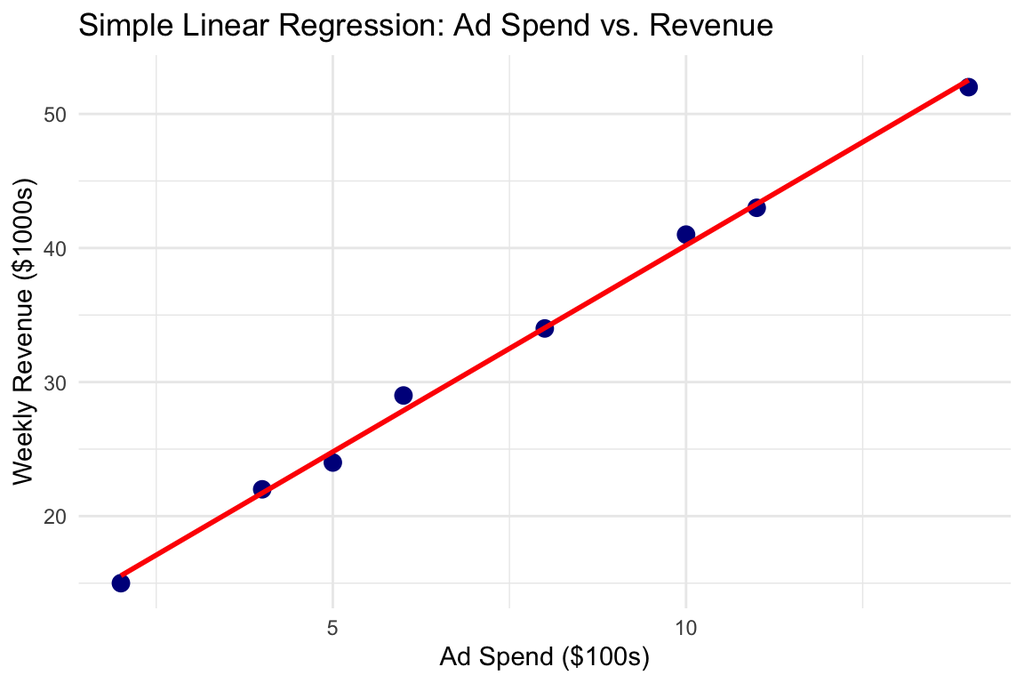

```r
ggplot(ad_data, aes(x = ad_spend, y = revenue)) +
  geom_point(color = "darkblue", size = 3) +
  geom_smooth(method = "lm", se = FALSE, color = "red") +
  labs(title = "Simple Linear Regression: Ad Spend vs. Revenue",
       x = "Ad Spend ($100s)",
       y = "Weekly Revenue ($1000s)") +
  theme_minimal()
```

# 4 Week 8 Key Formula Summary Sheet

| Concept / Metric | Formula | Notes |
| --- | --- | --- |
| **Experiment-Wise Error** | $\alpha_{\text{overall}} = 1 - (1 - \alpha)^c$ | $c = \frac{k(k-1)}{2}$ pairwise comparisons |
| **One-Way ANOVA $F$-Stat** | $F = \frac{MSC}{MSE} = \frac{SSC / (k - 1)}{SSE / (N - k)}$ | Always right-tailed |
| **Tukey’s HSD** | $\text{HSD} = q_{\alpha, \, k, \, N-k} \sqrt{\frac{MSE}{n}}$ | Equal group sizes $n$ |
| **OLS Slope ($b_1$)** | $b_1 = \frac{SS_{xy}}{SS_{xx}} = \frac{\sum (x_i - \bar{x})(y_i - \bar{y})}{\sum (x_i - \bar{x})^2}$ | Marginal change in $\hat{y}$ per unit $x$ |
| **OLS Intercept ($b_0$)** | $b_0 = \bar{y} - b_1 \bar{x}$ | Line always passes through $(\bar{x}, \bar{y})$ |
| **Standard Error ($s_e$)** | $s_e = \sqrt{\frac{SSE}{n - 2}}$ | Standard deviation of residuals |
| **Coeff. of Determination ($R^2$)** | $R^2 = \frac{SSR}{SST} = 1 - \frac{SSE}{SST}$ | Proportion of variance in $Y$ explained |

## Navigation & Practice

- **Practice & Exercises:** [Week 8 Practice & Exercises (Jupyter Notebook)](https://colab.research.google.com/github/telpirion/CumulativeStudyGuide/blob/main/Week8.ipynb)
- **Next Lesson:** Week 9 Study Guide — Regression Inference, Diagnostics, Correlation ($r^2$) & Multiple Regression